# DATASCI 385 - Experimental Methods

Lecture 06 - Texts for Discussion and More

Danilo Freire

danilo.freire@emory.edu

Department of Data and Decision Sciences  
Emory University

# Hi, there! 👋 Tudo bem? 😄🇧🇷

# Brief recap 📚

## Last time, we…

- Covered adding covariates with `lm_lin()`, centring, and sub-group analysis with interaction terms using `lm_robust`.
- Compared the Neyman-Rubin model (ATE) with the Ronald Fisher model (sharp null hypothesis)
- Talked about Type I and Type II errors
- Discussed sampling variability and how it affects the interpretation of experimental estimates
- Introduced randomisation inference with the `ri2` package
- Demonstrated RI with two examples, including one about female council heads and the other about runoff elections
- Real experiment: Analysed a paper using linear regression models as well as randomisation inference

## Today, we will…

- Talk a bit about `R` and the packages we have seen so far
- Discuss the next steps of your pre-analysis plan and the final project
- Discuss three papers
  - Kalla, J. & Broockman, D. (2015). [Campaign Contributions Facilitate Access to Congressional Officials: A Randomized Field Experiment](https://onlinelibrary.wiley.com/doi/full/10.1111/ajps.12180). American Journal of Political Science, 60(3): 545–558
  - Bertrand, M., & Mullainathan, S. (2004). [Are Emily and Greg more employable than Lakisha and Jamal? A field experiment on labor market discrimination](https://www.aeaweb.org/articles?id=10.1257%2F0002828042002561&ref=exo-insight). American Economic Review, 94(4), 991-1013
  - Chattopadhyay, R., & Duflo, E. (2004). [Women as policy makers: Evidence from a randomized policy experiment in India](https://onlinelibrary.wiley.com/doi/abs/10.1111/j.1468-0262.2004.00539.x). Econometrica, 72(5), 1409-1443
- But first…, let’s talk about your group work

## Group Work 🤝

### What I have in mind…

- I’d like you to start working on your pre-analysis plan as soon as possible 🤓
- I’ll give you some time to discuss your ideas and start writing your plan
- My plan is that you should slowly think about your final project, one step at a time
- What do you think about having two weeks to write the following:
  - Submit at most 2 paragraphs summarising an experiment that you want to develop in this course. At minimum, your summary should include a research question, why the question is important, and a rough sketch of how you plan to answer the question
- In three weeks:
  - Write a title and abstract for a paper you imagine writing based on your proposed experiment. Assume that your findings align with your theoretical predictions. Remember to establish why the findings matter for your intended audience
- In four weeks:
  - Outline your pre-analysis plan. Your outline should include sections on the research question, the experimental design, the data you will collect, and the analysis you will conduct

## What I have in mind…

- In five weeks:
  - Use `Quarto` and `DeclareDesign` to write your report and simulate your experiment
- In six weeks:
  - Revised outline, now including a new section titled “Potential Threats.” In this section, diagnose threats and briefly describe potential countermeasures. This new section should discuss false positives, statistical power, demand effects, noncompliance, spillover, and attrition
- In seven weeks:
  - Revised outline, now included a new section on “Heterogeneous Treatment Effects.” In this section, discuss how you might explore heterogeneity in treatment effects. This section should include a discussion of how you might use covariates to explore heterogeneity
- In eight weeks:
  - I will give you feedback on your outline and provide you with the simulated data for your experiment
  - You will have two weeks to write your final report
- Last week of class:
  - You will present your findings to the class

# R packages 📦

## `fabricatr`: Simulating data for experiments

- `fabricatr` is a very useful package!
- You guys have no idea how much time (and money) it has saved me 😅
- It is straightforward to use and has *a bunch* of functions
- They even have a tutorial showing how to [create common social science data structures](https://declaredesign.org/r/fabricatr/articles/common_social.html) (and more!)
- So I recommend that you check it out and play around with it 😉
- The source code is available at https://github.com/DeclareDesign/fabricatr

## `fabricatr`: Simulating data for experiments

```r
library(fabricatr)

voters <- fabricate(
  N = 1000,
  group_id = rep(1:10, 100),
  ideology = draw_normal_icc(mean = 0, N = N, clusters = group_id, ICC = 0.7),
  ideological_label = draw_ordered(
    x = ideology, break_labels = c("Very Conservative", "Conservative", "Liberal", "Very Liberal")
  ),
  Q1_immigration = draw_likert(x = ideology, min = -5, max = 5, bins = 7),
  Q2_defence = draw_likert(x = ideology + 0.5, min = -5, max = 5, bins = 7),
  treatment = draw_binary(0.5, N = N),
  proposition_vote = draw_binary(latent = ideology + 1.2 * treatment, link = "probit")
)

head(voters)
```

```
    ID group_id   ideology ideological_label Q1_immigration Q2_defence
1 0001        1 -0.8647192      Conservative              3          4
2 0002        2  1.5287829      Very Liberal              5          5
3 0003        3 -0.2613002      Conservative              4          4
4 0004        4 -1.1130973 Very Conservative              3          4
5 0005        5 -1.2824594 Very Conservative              3          3
6 0006        6  3.1156642      Very Liberal              6          7
  treatment proposition_vote
1         0                0
2         1                1
3         1                1
4         0                0
5         0                1
6         0                1
```

## `randomizr`: Randomisation for experiments

- `randomizr` is another package that I use a lot
- It is the easiest way to randomise your treatment assignment
- It also has all the types of randomisation we use in experiments
  - Simple randomisation with `simple_ra()`
  - Complete randomisation with `complete_ra()`
  - Block randomisation with `block_ra()`
  - Cluster randomisation with `cluster_ra()`
  - Block and cluster randomisation with `block_and_cluster_ra()`
- The source code is available at https://github.com/DeclareDesign/randomizr/

## `randomizr`: Randomisation for experiments

```r
library(randomizr)

# Simple randomisation
set.seed(42)
N <- 100
Z <- simple_ra(N = N, prob = 0.5)
table(Z)
```

```
Z
 0  1
45 55
```

```r
# Complete randomisation
Z <- complete_ra(N = N, m = 50)
table(Z)
```

```
Z
 0  1
50 50
```

```r
# Block randomisation
set.seed(42)
N <- 100
participants <- data.frame(
  id = 1:N,
  gender = sample(c("Female", "Male"), N, replace = TRUE)
)

participants$assignment <- block_ra(
  blocks = participants$gender
)
table(participants$assignment, participants$gender)
```

```
    Female Male
  0     22   28
  1     22   28
```

```r
# Cluster randomisation
set.seed(42)
students <- data.frame(
  student_id = 1:2000,
  school_id = rep(1:10, each = 200)
  # Each school (10) is a cluster of 200 students
)

# `m = 5` to assign 5 clusters to the treatment condition
students$assignment <- cluster_ra(
  clusters = students$school_id, m = 5
)
table(students$assignment)
```

```
   0    1
1000 1000
```

## `estimatr`: Estimating treatment effects

- We have already seen `estimatr` in action
- The package is particularly useful to estimate linear models with robust standard errors
  - Economists use OLS for *everything* 😅
- But you can also use it to estimate instrumental variables models, difference-in-differences, and more
- `estimatr` integrates well with the [tidyverse](https://www.tidyverse.org/), so you can use it with `dplyr`, `ggplot2`, and other packages
- Source code: https://github.com/DeclareDesign/estimatr

## `estimatr`: Estimating treatment effects

```r
library(estimatr)
fit <- lm_robust(Fertility ~ Agriculture + Catholic, data = swiss)
tidy(fit)
```

```
         term   estimate  std.error statistic      p.value    conf.low
1 (Intercept) 59.8639237 5.47384281 10.936361 3.934173e-14 48.83211840
2 Agriculture  0.1095281 0.10305115  1.062852 2.936478e-01 -0.09815783
3    Catholic  0.1149621 0.03854836  2.982283 4.651169e-03  0.03727301
   conf.high df   outcome
1 70.8957290 44 Fertility
2  0.3172141 44 Fertility
3  0.1926512 44 Fertility
```

## `estimatr`: `ggplot2` integration

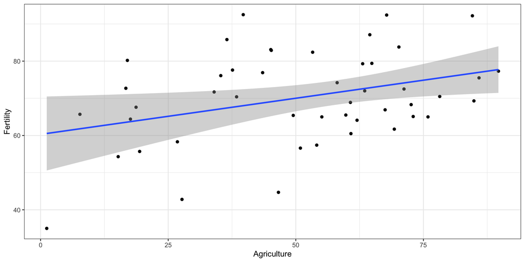

```r
library(ggplot2)
ggplot(swiss, aes(x = Agriculture, y = Fertility)) +
  geom_point() +
  geom_smooth(method = "lm_robust") +
  theme_bw()
```

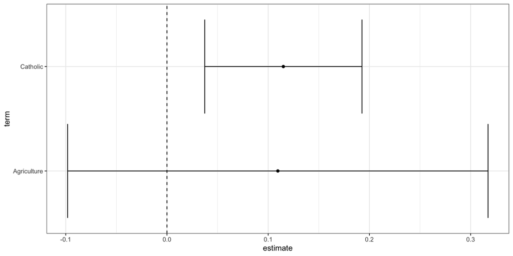

```r
library(dplyr)
fit %>%
  tidy %>%
  filter(term != "(Intercept)") %>%
  ggplot(aes(y = term, x = estimate)) +
  geom_vline(xintercept = 0, linetype = 2) +
  geom_point() +
  geom_errorbarh(aes(xmin = conf.low, xmax = conf.high, height = 0.1)) +
  theme_bw()
```

## `ri2`: Randomisation inference

- The last package we have seen is `ri2`
- An easy way to estimate sharp null hypothesis tests
- Source code: https://github.com/acoppock/ri2

```r
library(ri2)
N <- 100
declaration <- declare_ra(N = N, m = 50)

Z <- conduct_ra(declaration)
X <- rnorm(N)
Y <- .9 * X + .2 * Z + rnorm(N)
dat <- data.frame(Y, X, Z)

ri_out <-
  conduct_ri(
    formula = Y ~ Z,
    declaration = declaration,
    assignment = "Z",
    sharp_hypothesis = 0,
    data = dat
  )
summary(ri_out)
plot(ri_out)
```

```
  term   estimate two_tailed_p_value
1    Z -0.2361121              0.396
```

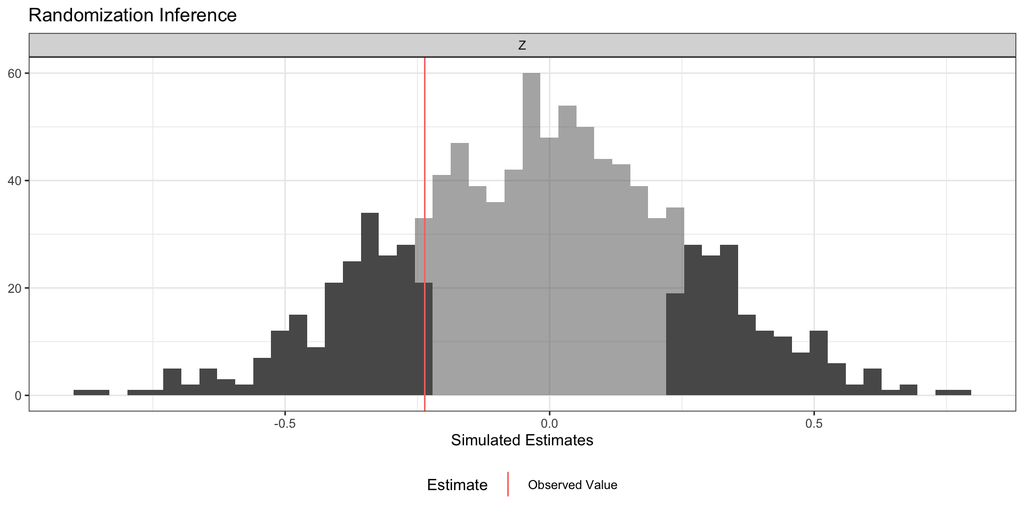

# Questions? 😉

# Papers for Discussion 📚

## Kalla, J. & D. Broockman. 2015

### [Campaign Contributions Facilitate Access to Congressional Officials: A Randomized Field Experiment](https://onlinelibrary.wiley.com/doi/full/10.1111/ajps.12180)

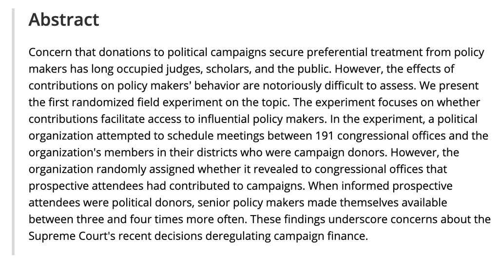

[Article link](https://doi.org/10.1111/ajps.12180) and [replication data](https://dataverse.harvard.edu/dataset.xhtml?persistentId=doi:10.7910/DVN/28582)

## Overview

- Overview
  - Do campaign donations secure preferential treatment from policymakers?
  - Challenge: It is hard to isolate the effect of donations on policymakers’ behaviour
  - First randomised field experiment on campaign contributions and access
  - Do donations *facilitate access* to influential policymakers?
- The Experiment
  - A political organisation tried to schedule meetings between congressional offices and their members (who were donors)
  - The organisation randomly revealed to offices if attendees were donors
  - Key finding: When informed attendees were donors, policymakers were available 3-4 times more often
  - Underscores concerns about campaign finance deregulation
- Hypotheses
  - H1: Senior policy makers will make themselves available more often when they know that prospective attendees are political donors
  - H2: That knowing about donations matters more when scheduling meetings with higher level officials
- Why Should We Care?
  - Political Inequality: Campaign donations may amplify the voices of the wealthy
  - Policy Decisions: Understanding who has access informs how policies are made
  - Democracy: This research is crucial for a more equitable political system
- Policy Relevance
  - Campaign finance reform: Findings can inform debates about the necessity of these reforms
  - Regulation: This study helps to clarify the relationship between campaign donations and access to power
  - Supreme Court decisions: Results bear on recent deregulation (at the time)

## Treatment

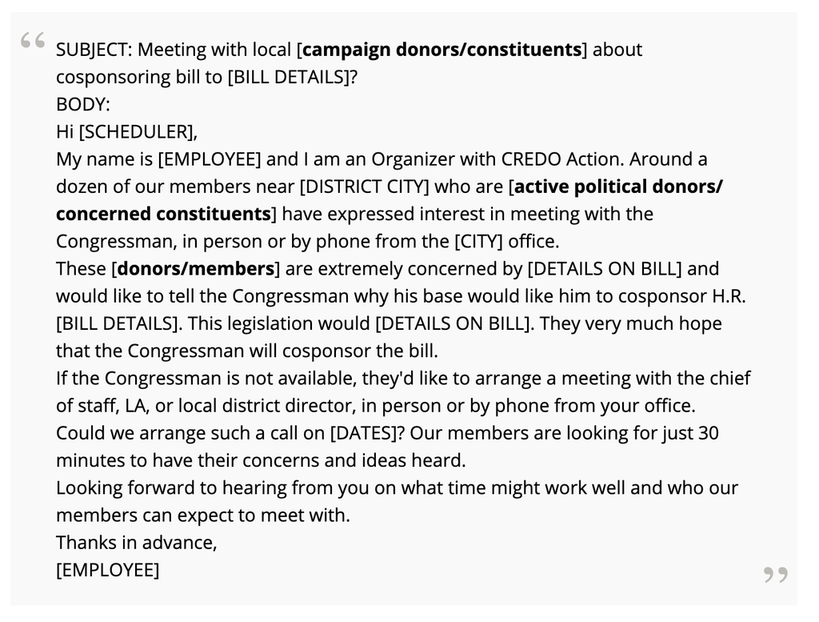

## Follow-up

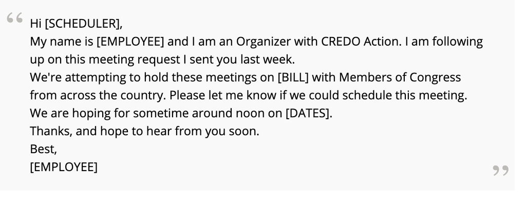

## Results

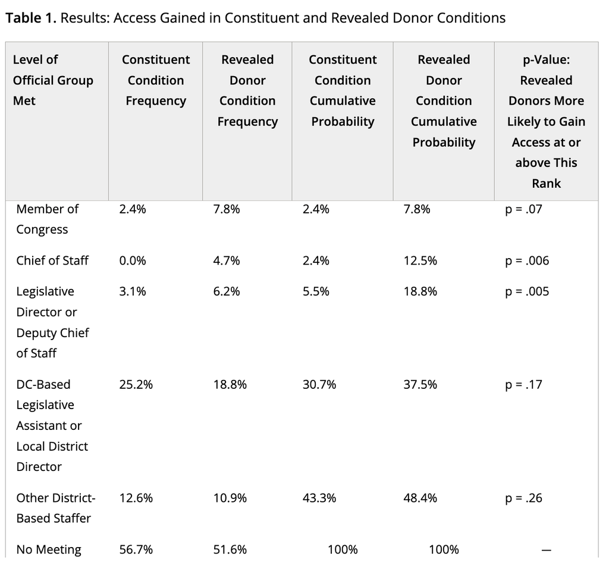

## Results (cont.)

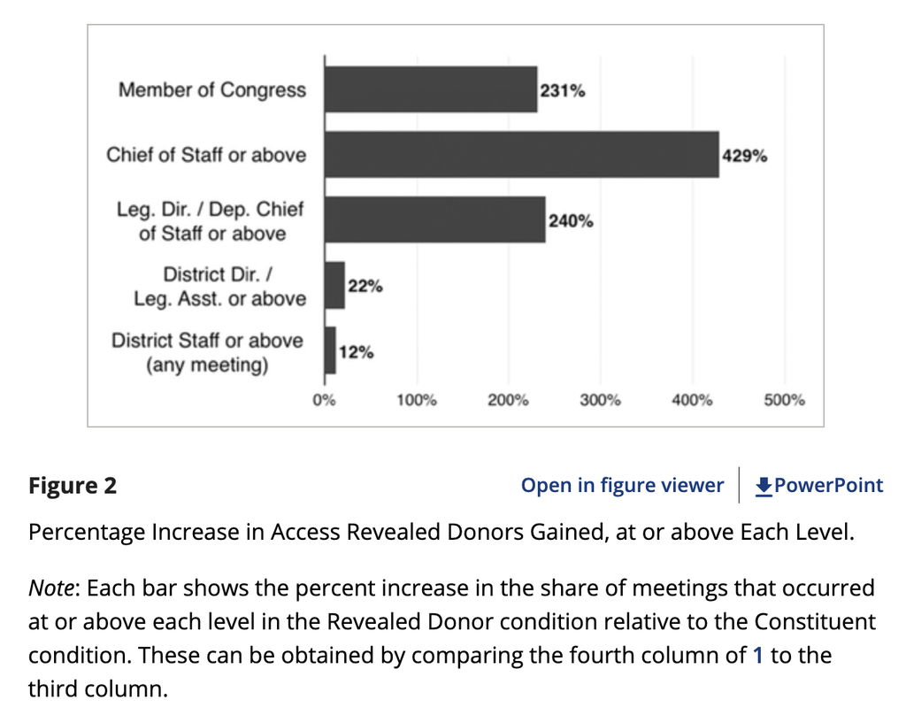

## Discussion

- Implications
  - The study provides evidence that campaign donations can facilitate access to policymakers
  - The findings underscore concerns about the influence of money in politics
  - The results suggest that campaign finance reform may be necessary to ensure a more equitable political system
- Limitations
  - Mechanisms: The exact reasons why legislators reacted to donations needs further study
  - Causal Chain: The link between access and influence requires further investigation
  - Generalisability: More studies with different actors, organisations and contexts are required

# Bertrand and Mullainathan (2004) 🇺🇸

## Bertrand, M., & Mullainathan, S. (2004)

### Are Emily and Greg More Employable than Lakisha and Jamal? A Field Experiment on Labor Market Discrimination

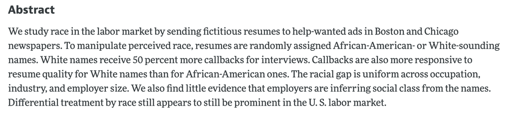

[Article link](https://www.aeaweb.org/articles?id=10.1257%2F0002828042002561&ref=exo-insight) and [replication data](http://doi.org/10.3886/E116023V1)

## Overview

- Overview
  - Research Question: Is there racial bias in callback rates for job interviews?
  - Challenge: Difficult to isolate racial discrimination from other factors
  - Method: A field experiment using fictitious resumes
  - Manipulation: Randomly assigned names to signal race (White vs. African-American)
- The Experiment
  - Fictitious Resumes: Sent to real job ads in Boston and Chicago
  - Name Manipulation: Resumes randomly assigned White-sounding or African-American-sounding names
  - Callback Rate: Measured the rate at which resumes received interview requests
  - Resume Quality: Varied to test if bias differs by qualification
- Hypotheses
  - H1: White names will receive a significantly higher callback rate
  - H2: The racial gap in callback rates will persist even for higher quality resumes
- Why Should We Care?
  - Racial Inequality: Persistent racial disparities in the labour market
  - Discrimination: Understanding the mechanisms of racial discrimination
  - Policy Implications: Informative for policies aimed at promoting equal opportunity
- Policy Relevance
  - Affirmative Action: Assessing the effectiveness of current policies
  - Anti-discrimination Law: Evidence for the continued relevance of anti-discrimination efforts
  - Social Justice: Highlighting ongoing challenges to racial equality

## Results

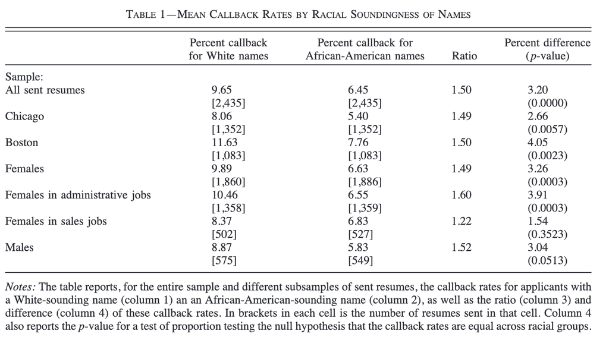

## Results

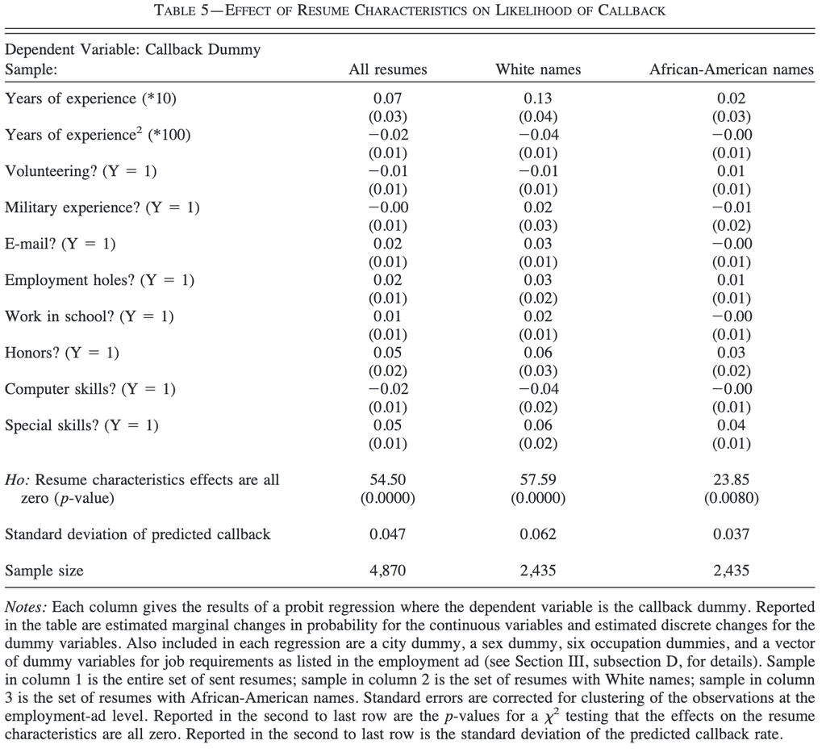

## Results

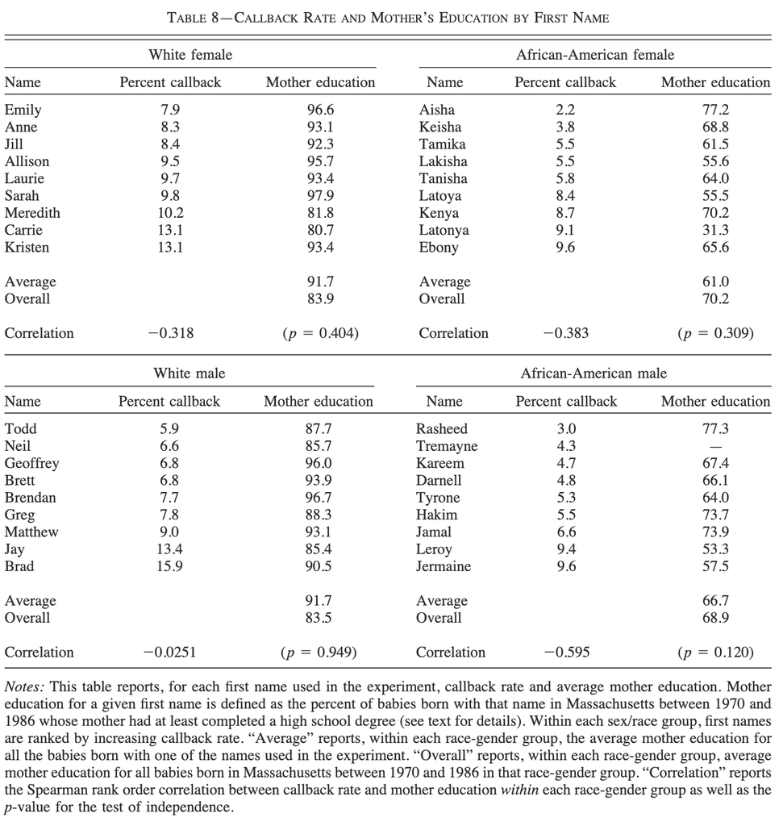

## Discussion

- Key Findings
  - Significant Racial Gap: White names receive 50% more callbacks
  - Resume Quality Matters Less for African-Americans: Improved credentials do not close the racial gap
  - Uniformity of Gap: Bias is consistent across occupations, industries, and employer types
- Implications
  - Persistent Discrimination: Racial bias remains a significant factor in the labour market
  - Limited Returns to Human Capital: Efforts to improve skills may not equally benefit all racial groups in terms of job access
  - Challenges for Policy: Highlights the complexity of addressing racial inequality, requiring more than just skills-based interventions
- Limitations
  - Callback as Outcome: Measures access to interview, not job offers or wages
  - Name as Proxy for Race: Confounding factors (social class inferences from names) are possible, although tested against
  - Generalisability: Focus on specific job categories and cities (Boston & Chicago)

# Chattopadhyay and Duflo (2004) 🇮🇳

## Chattopadhyay, R., & Duflo, E. (2004)

### Women as Policy Makers: Evidence from a Randomized Policy Experiment in India

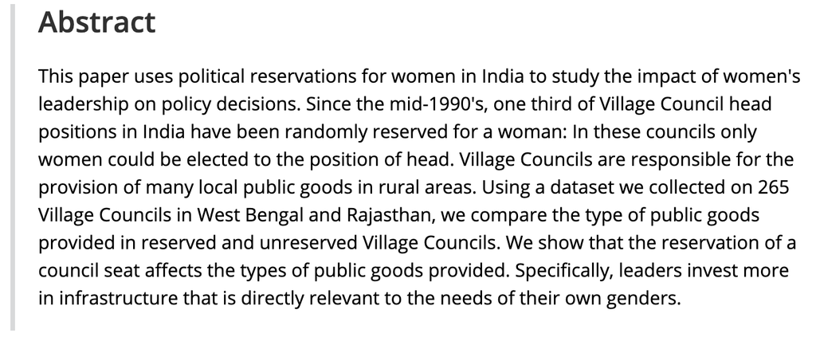

[Article link](https://doi.org/10.1111/j.1468-0262.2004.00539.x)

## Overview

- Overview
  - How does women’s leadership affect policy decisions?
  - Challenge: It is hard to isolate the effect of representation on policy choices
  - India: A unique experiment with reserved seats for women in local government
  - A quasi-experimental study to investigate this effect
- The Experiment
  - Randomised: One-third of Village Council head positions were randomly reserved for women
  - Dataset collected in 265 Village Councils in West Bengal and Rajasthan
  - Comparison: type of public goods in reserved and unreserved Village Councils
  - Key Finding: Reservation affects the types of public goods provided, with leaders investing more in infrastructure relevant to their own gender
- Hypotheses
  - H1: Leaders will invest more in infrastructure that is directly relevant to the needs of their own genders
  - H2: The effect of reservation is caused by gender, and not other characteristics of women leaders
- Why Should We Care?
  - Underrepresentation: Women are underrepresented in political positions worldwide
  - Policy Impact: Understanding if women make different policy choices
  - Political Equality: Is vital for representative democracy
- Policy Relevance
  - Affirmative Action: Findings inform debates about the necessity of affirmative action in politics
  - Decentralisation: Results shed light on the consequences of decentralising power in India
  - Institutions: Helps understand how the design of political institutions can affect outcomes

## Intervention

- Context
  - India: A constitutional amendment required the reservation of one-third of all positions of village chief (Pradhan) to women
  - Implementation: This was implemented in two states: West Bengal and Rajasthan
  - GPs: Local Village Councils, which have influence on local public goods
- Intervention
  - Randomisation: GPs were randomly selected to be reserved for women
  - Treatment: Whether the village council was randomly reserved for a woman leader
    - Control Condition: The council is open to all candidates
- Outcome Measurement
  - Primary Outcome: The types of public goods provided
  - Focus: Investments in specific goods such as drinking water, roads, and other local infrastructure
  - Secondary Outcome: requests and complaints made by different genders
- The Process
  - Allocation of GPs for reservation: This was done based on specific pre-existing lists, and the selection was effectively random
  - Implementation: A specific set of rules ensures the random selection
  - Data collection: Surveys of the investment made in the villages, and interviews with the village leaders
  - Surveys collected in the summer of 2000 (West Bengal and Rajasthan) and at the end of 2002 (Rajasthan)

## Balance test

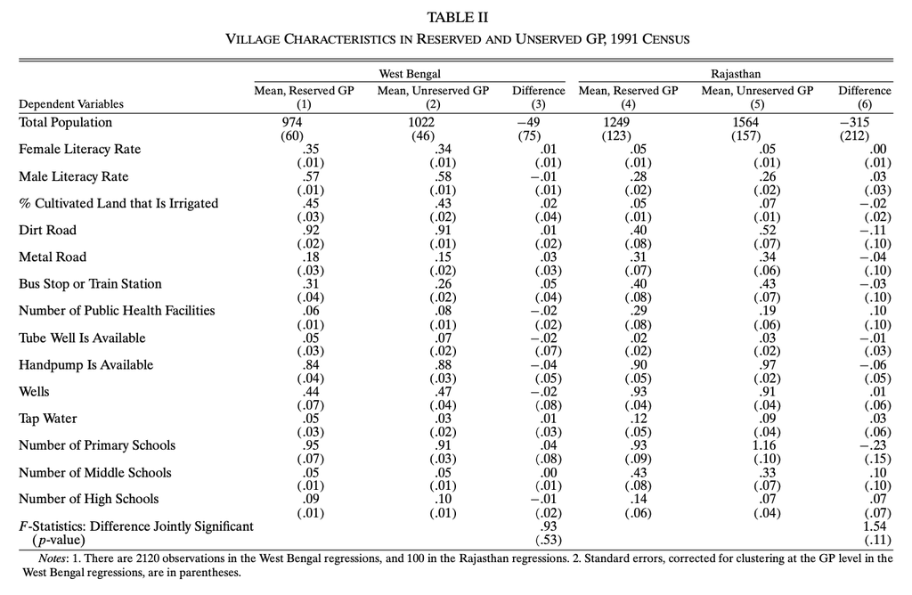

## Results

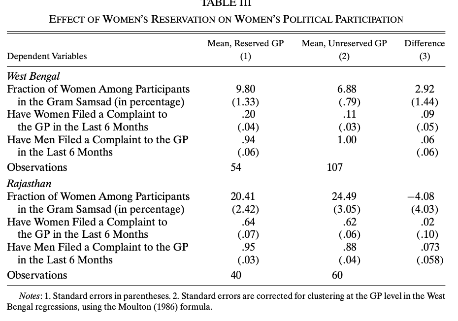

## Results (cont.)

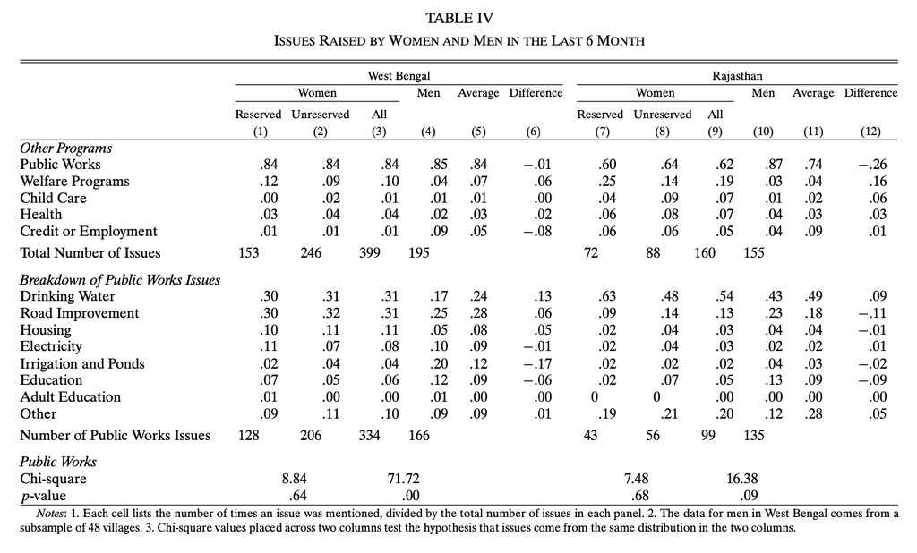

## Results (cont.)

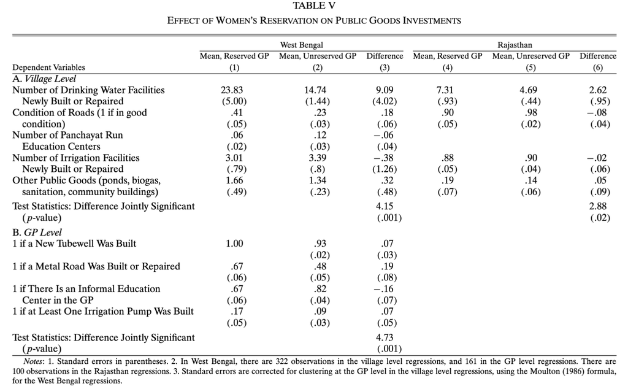

## Discussion

- Implications
  - Policy choices are affected by the gender of the decision maker
  - Women leaders invest more in public goods aligned with women’s priorities, and vice versa
  - This effect is causal, and not driven by characteristics of women leaders, but their gender per se
- Theoretical Contribution
  - Evidence of the effect of identity on the policymaking process
  - Contradicts Downsian models of policy preferences (which assume that politicians are purely self-interested)
  - Shows the importance of the design of political institutions in ensuring the representation of different social groups
- Limitations
  - The study focuses on local governance in India, and may not generalise to other contexts
  - The model does not consider dynamic effects of the policy
  - Mechanisms: the exact mechanisms of the decision-making process are still not fully clear

# Questions? 😉

# And that’s it for today! 🎉

# All the very best! See you soon! 🚀